# Read in the data

```python
import pandas as pd
import numpy
import re

data_files = [
    "ap_2010.csv",
    "class_size.csv",
    "demographics.csv",
    "graduation.csv",
    "hs_directory.csv",
    "sat_results.csv"
]

data = {}

for f in data_files:
    d = pd.read_csv("schools/{0}".format(f))
    data[f.replace(".csv", "")] = d
```

# Read in the surveys

```python
all_survey = pd.read_csv("schools/survey_all.txt", delimiter="\t", encoding='windows-1252')
d75_survey = pd.read_csv("schools/survey_d75.txt", delimiter="\t", encoding='windows-1252')
survey = pd.concat([all_survey, d75_survey], axis=0)

survey["DBN"] = survey["dbn"]

survey_fields = [
    "DBN",
    "rr_s",
    "rr_t",
    "rr_p",
    "N_s",
    "N_t",
    "N_p",
    "saf_p_11",
    "com_p_11",
    "eng_p_11",
    "aca_p_11",
    "saf_t_11",
    "com_t_11",
    "eng_t_11",
    "aca_t_11",
    "saf_s_11",
    "com_s_11",
    "eng_s_11",
    "aca_s_11",
    "saf_tot_11",
    "com_tot_11",
    "eng_tot_11",
    "aca_tot_11",
]
survey = survey.loc[:,survey_fields]
data["survey"] = survey
```

# Add DBN columns

```python
data["hs_directory"]["DBN"] = data["hs_directory"]["dbn"]

def pad_csd(num):
    string_representation = str(num)
    if len(string_representation) > 1:
        return string_representation
    else:
        return "0" + string_representation

data["class_size"]["padded_csd"] = data["class_size"]["CSD"].apply(pad_csd)
data["class_size"]["DBN"] = data["class_size"]["padded_csd"] + data["class_size"]["SCHOOL CODE"]
```

# Convert columns to numeric

```python
cols = ['SAT Math Avg. Score', 'SAT Critical Reading Avg. Score', 'SAT Writing Avg. Score']
for c in cols:
    data["sat_results"][c] = pd.to_numeric(data["sat_results"][c], errors="coerce")

data['sat_results']['sat_score'] = data['sat_results'][cols[0]] + data['sat_results'][cols[1]] + data['sat_results'][cols[2]]

def find_lat(loc):
    coords = re.findall("\(.+, .+\)", loc)
    lat = coords[0].split(",")[0].replace("(", "")
    return lat

def find_lon(loc):
    coords = re.findall("\(.+, .+\)", loc)
    lon = coords[0].split(",")[1].replace(")", "").strip()
    return lon

data["hs_directory"]["lat"] = data["hs_directory"]["Location 1"].apply(find_lat)
data["hs_directory"]["lon"] = data["hs_directory"]["Location 1"].apply(find_lon)

data["hs_directory"]["lat"] = pd.to_numeric(data["hs_directory"]["lat"], errors="coerce")
data["hs_directory"]["lon"] = pd.to_numeric(data["hs_directory"]["lon"], errors="coerce")
```

# Condense datasets

```python
class_size = data["class_size"]
class_size = class_size[class_size["GRADE "] == "09-12"]
class_size = class_size[class_size["PROGRAM TYPE"] == "GEN ED"]

class_size = class_size.groupby("DBN").agg(numpy.mean)
class_size.reset_index(inplace=True)
data["class_size"] = class_size

data["demographics"] = data["demographics"][data["demographics"]["schoolyear"] == 20112012]

data["graduation"] = data["graduation"][data["graduation"]["Cohort"] == "2006"]
data["graduation"] = data["graduation"][data["graduation"]["Demographic"] == "Total Cohort"]
```

# Convert AP scores to numeric

```python
cols = ['AP Test Takers ', 'Total Exams Taken', 'Number of Exams with scores 3 4 or 5']

for col in cols:
    data["ap_2010"][col] = pd.to_numeric(data["ap_2010"][col], errors="coerce")
```

# Combine the datasets

```python
combined = data["sat_results"]

combined = combined.merge(data["ap_2010"], on="DBN", how="left")
combined = combined.merge(data["graduation"], on="DBN", how="left")

to_merge = ["class_size", "demographics", "survey", "hs_directory"]

for m in to_merge:
    combined = combined.merge(data[m], on="DBN", how="inner")

combined = combined.fillna(combined.mean())
combined = combined.fillna(0)
```

# Add a school district column for mapping

```python
def get_first_two_chars(dbn):
    return dbn[0:2]

combined["school_dist"] = combined["DBN"].apply(get_first_two_chars)
```

# Find correlations

```python
correlations = combined.corr()
correlations = correlations["sat_score"]
print(correlations)
```

```
SAT Critical Reading Avg. Score    0.986820
SAT Math Avg. Score                0.972643
SAT Writing Avg. Score             0.987771
sat_score                          1.000000
AP Test Takers                     0.523140
                                     ...
priority08                              NaN
priority09                              NaN
priority10                              NaN
lat                               -0.121029
lon                               -0.132222
Name: sat_score, Length: 67, dtype: float64
```

# Plotting survey correlations

```python
# Remove DBN since it's a unique identifier, not a useful numerical value for correlation.
survey_fields.remove("DBN")
```

```python
import matplotlib as plt
```

```python
# find which fields came from survey of parents, teachers, students
overlap_fields = (combined.columns & survey_fields)
# overlap = combined.loc[:, pts_survey_fields]
print(overlap_fields)
```

```
Index(['rr_s', 'rr_t', 'rr_p', 'N_s', 'N_t', 'N_p', 'saf_p_11', 'com_p_11',
       'eng_p_11', 'aca_p_11', 'saf_t_11', 'com_t_11', 'eng_t_11', 'aca_t_11',
       'saf_s_11', 'com_s_11', 'eng_s_11', 'aca_s_11', 'saf_tot_11',
       'com_tot_11', 'eng_tot_11', 'aca_tot_11'],
      dtype='object')
```

```python
# print(combined[['sat_score']].corrwith(combined[overlap_fields]))
sat_survey_corr = combined.corr()
sat_survey_corr = sat_survey_corr['sat_score']
# print(sat_survey_corr)
print(sat_survey_corr[overlap_fields].sort_values())
```

```
com_p_11     -0.115073
rr_t         -0.023386
eng_p_11      0.020254
aca_p_11      0.035155
eng_t_11      0.036906
rr_p          0.047925
com_tot_11    0.077310
com_t_11      0.082419
eng_tot_11    0.100102
saf_p_11      0.122913
aca_t_11      0.132348
com_s_11      0.187370
aca_tot_11    0.190966
eng_s_11      0.213822
rr_s          0.232199
N_t           0.291463
saf_t_11      0.313810
saf_tot_11    0.318753
saf_s_11      0.337639
aca_s_11      0.339435
N_p           0.421530
N_s           0.423463
Name: sat_score, dtype: float64
```

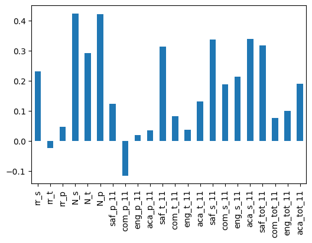

```python
# %matplotlib inline
# sat_survey_corr[overlap_fields].plot.bar()
# combined.corr()["sat_score"][survey_fields].plot.bar()
combined.corr()["sat_score"][survey_fields].plot(kind='bar')
```

# Sat Scores are highly correlated with:

- **N_t** Number of teacher respondents
- **saf_t_11** Safety and Respect score based on teacher responses
- **saf_tot_11** Safety and Respect total score
- **saf_s_11** Safety and Respect score based on student responses
- **aca_s_11** Academic expectations score based on student responses
- **N_p** Number of parent respondents
- **N_s** Number of student respondents

```python
# source: https://data.cityofnewyork.us/api/views/mnz3-dyi8/files/220be57a-7c05-48dc-94de-b11a882ca9da?download=true&filename=2011%20School%20Survey.zip
Survey_Data_Dictionary = ["dbn", "sch_type", "location", "enrollment", "borough",
                          "principal", "studentsurvey", "rr_s", "rr_t", "rr_p",
                          "N_s", "N_t", "N_p", "nr_s", "nr_t", "nr_p", "saf_p_10",
                          "com_p_10", "eng_p_10", "aca_p_10", "saf_t_10", "com_t_10",
                          "eng_t_10", "aca_t_10", "saf_s_10", "com_s_10", "eng_s_10",
                          "aca_s_10", "saf_tot_10", "com_tot_10", "eng_tot_10", "aca_tot_10",
                          "Field Series", "Column AG through Column CA", "Column CB through Column LV",
                          "Column LW through Column VQ", "Column VR through Column YS",
                          "Column YT through Column AMY", "Column AMZ through Column BBE",
                          "Column BBF through Column BDD", "Column BDE through Column BNB",
                          "Column BNC through BWZ", "Field Convention", "p_q1", "p_q1a", "p_q1a_1",
                          "p_N_q1_1", "t_q1", "t_q1a", "t_q1a_1", "t_N_q1_1", "s_q1", "s_q1a", "s_q1a_1",
                          "s_N_q1_1"]

shared = (Survey_Data_Dictionary and survey_fields)
print("shared columns: ", shared)
diffs = (set(Survey_Data_Dictionary) - set(survey_fields))
print("diffs columns: ", diffs)
```

[output not shown]

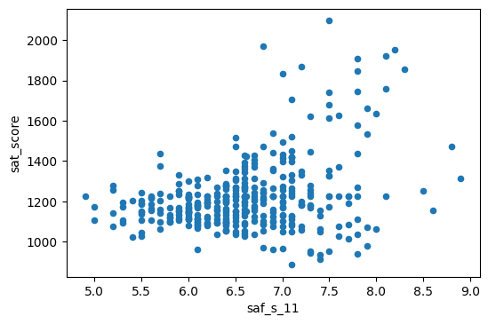

```python
# plt.scatter(combined['sat_score'], combined['saf_s_11'])
combined.plot.scatter(x='saf_s_11', y='sat_score')
```

# Safety vs SAT Score Plot

- Assuming Safety has a direct affect on SAT scores.
- Safety seems to have little affect on SAT scores until a score of 6.3+
- Then SAT score seems to be positively correlated with Safety.
- There seems to be a split though. Some schools it seems to be heavily correlated while other SAT scores remain low.

```python
print(combined['boro'].value_counts())
combined.pivot_table(index='boro', values=['saf_s_11', 'sat_score'], aggfunc='mean')
```

```
Brooklyn         106
Bronx             93
Manhattan         90
Queens            64
Staten Island     10
Name: boro, dtype: int64
```

| boro | saf_s_11 | sat_score |
| --- | --- | --- |
| Bronx | 6.606577 | 1157.598203 |
| Brooklyn | 6.370755 | 1181.364461 |
| Manhattan | 6.831370 | 1278.331410 |
| Queens | 6.721875 | 1286.753032 |
| Staten Island | 6.530000 | 1382.500000 |

- Manhattan and Queens have higher safety & SAT scores
- Brooklyn has low safety & SAT scores

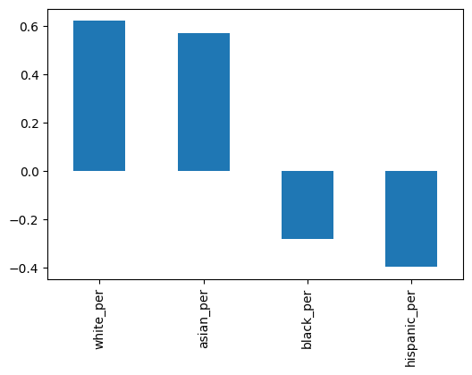

```python
race_ratios = ["white_per", "asian_per", "black_per", "hispanic_per"]
sat_survey_corr[race_ratios].plot.bar()
# sat_survey_corr['white_per']
```

# Race Ratio vs SAT Score Correlation

- SAT Score seems to be positively correlated with it's ratio of Asian & White students
- SAT Score seems to be negatively correlated with it's ratio of Black & Hispanic students

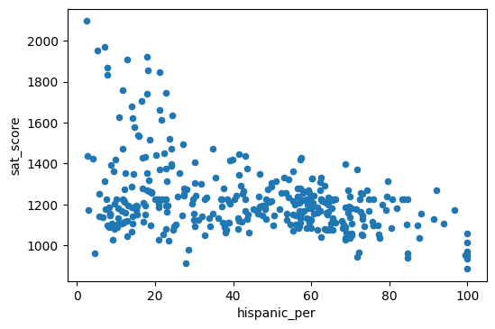

```python
combined.plot.scatter(x='hispanic_per', y='sat_score')
```

# Hispanic Pop Ratio vs SAT Score

- For most of the schools, the ratio of hispanic student's seems to have no affect on SAT scores
- There are outliers at 100% hispanic schools & schools blow ~25% hispanic students

This suggests that there isn't a strong correlation between Hispanic Students & SAT scores and more is going on.

```python
print(combined[combined["hispanic_per"] > 95]["SCHOOL NAME"])
```

```
44                         MANHATTAN BRIDGES HIGH SCHOOL
82      WASHINGTON HEIGHTS EXPEDITIONARY LEARNING SCHOOL
89     GREGORIO LUPERON HIGH SCHOOL FOR SCIENCE AND M...
125                  ACADEMY FOR LANGUAGE AND TECHNOLOGY
141                INTERNATIONAL SCHOOL FOR LIBERAL ARTS
176     PAN AMERICAN INTERNATIONAL HIGH SCHOOL AT MONROE
253                            MULTICULTURAL HIGH SCHOOL
286               PAN AMERICAN INTERNATIONAL HIGH SCHOOL
Name: SCHOOL NAME, dtype: object
```

These are schools seem to be dedicated to immigrants learning english, so a lower SAT score makes sense.

```python
lowhisp_highscore = combined[combined["hispanic_per"] < 10]
print(lowhisp_highscore[lowhisp_highscore["sat_score"] > 1800]["SCHOOL NAME"])
```

```
37                                STUYVESANT HIGH SCHOOL
151                         BRONX HIGH SCHOOL OF SCIENCE
187                       BROOKLYN TECHNICAL HIGH SCHOOL
327    QUEENS HIGH SCHOOL FOR THE SCIENCES AT YORK CO...
356                  STATEN ISLAND TECHNICAL HIGH SCHOOL
Name: SCHOOL NAME, dtype: object
```

# Low Hispanic Pop Ratio vs High SAT Score

- These are technical schools that only admit students that test highly
- These are schools in New York, which is further from the southern border.

Both of these explain the bias from high SAT scores & low hispanic population ratios

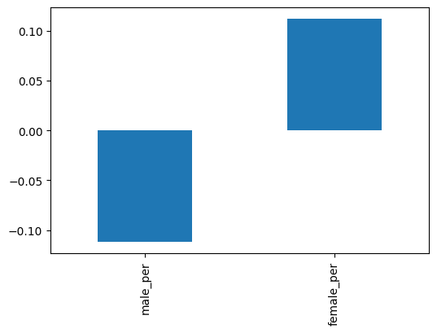

```python
gender_ratios = ["male_per", "female_per"]
sat_survey_corr[gender_ratios].plot.bar()
```

# Gender Ratio vs SAT Score

- the male ratio is negatively correlated with SAT scores
- the female ratio is positively correlated with SAT scores

Neither correlation seems to be strong.

```python
highpop_female_schools = combined[combined["female_per"] > 60]
print(highpop_female_schools[highpop_female_schools["sat_score"] > 1700]["SCHOOL NAME"])
```

```
5                         BARD HIGH SCHOOL EARLY COLLEGE
26                         ELEANOR ROOSEVELT HIGH SCHOOL
60                                    BEACON HIGH SCHOOL
61     FIORELLO H. LAGUARDIA HIGH SCHOOL OF MUSIC & A...
302                          TOWNSEND HARRIS HIGH SCHOOL
Name: SCHOOL NAME, dtype: object
```

These are selective Liberal Arts schools with selective admissions processes.

```python
combined['ap_per'] = combined['AP Test Takers '] / combined['total_enrollment']
```

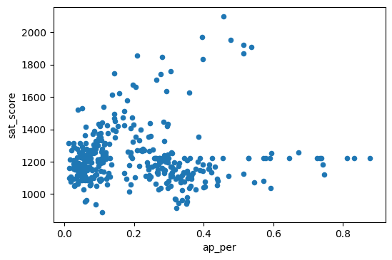

```python
combined.plot.scatter(x='ap_per', y='sat_score')
```

# Percent Students Taking AP vs SAT Score

- There seems to be a very weak correlation between students taking AP classes & SAT scores